# B5_Cac_khai_niem

[figure not shown]

| **Leonhard Euler (1707-1783)** | *Bản đồ Königsberg thời Euler* |
| --- | --- |

**Bài toán:** Liệu có thể đi một lần qua tất cả 7 chiếc cầu mà không có cầu nào phải lặp lại hay không?

[figure not shown]

# Chương 2: Lý thuyết đồ thị

## 1. Các khái niệm cơ bản

## 2. Biểu diễn đồ thị

## 3. Các thuật toán duyệt đồ thị

## 4. Đồ thị Euler và đồ thị Hamilton

## 5. Cây và khung của đồ thị

## 6. Bài toán tìm đường đi ngắn nhất

[figure not shown]

**1. Đồ thị trong thực tế**

**2. Các loại đồ thị**

**3. Bậc của đỉnh**

**4. Đồ thị con**

**5. Đường đi, chu trình và tính liên thông**

**6. Một số loại đồ thị đặc biệt**

**7. Bài toán tô màu đồ thị**

# 1. Đồ thị trong thực tế

- Chú ý: đây ko phải là thuật ngữ đồ thị trong toán
- Là cấu trúc rời rạc có tính trực quan cao, rất tiện ích để biểu diễn các quan hệ

[figure not shown]

- Ứng dụng trong: mạng máy tính, mạng giao thông, mạng cung cấp nước, mạng điện, lập lịch, tối ưu hoá luồng, thiết kế mạch, quy hoạch phát triển, phân tích gen, trò chơi máy tính, chương trình dịch, thiết kế hướng đối tượng,...

[figure not shown]

Tập các đỉnh

Tập các cạnh: có hướng và vô hướng

Đồ thị là một Cấu trúc rời rạc bao gồm các đỉnh và các cạnh nối các đỉnh này.

[figure not shown]

Đỉnh = Các phòng

Cạnh = Cửa thông phòng hoặc Hành lang

- Tìm đường đi trên mê cung chuyển về bài toán tìm đường đi trên đồ thị.

[figure not shown]

Đỉnh = Nguồn, Công tắc, Điện trở

Cạnh = Đoạn dây nối

[figure not shown]

**?**: Những câu lệnh nào thực hiện trước $S_6$

Đỉnh = Câu lệnh

Cạnh = Yêu cầu trình tự

[figure not shown]

Đỉnh = Máy tính

Cạnh = Tốc độ truyền tin

- Đồ thị có trọng số

[figure not shown]

Đỉnh = Trạm trung chuyển

Cạnh = Tuyến đường

Từ đây ta có thể có những yêu cầu để đi từ A đến B:

- Số lần chuyển xe là ít nhất
- Thời gian hành trình là ít nhất

[figure not shown]

Đỉnh = Nút giao lộ

Cạnh = Đường nối các nút giao lộ

Đồ thị có trọng số (khoảng cách, mật độ, phí), có hướng (1 chiều, 2 chiều, loại phương tiên), từ đó xây dựng được các bài toán tìm đường đi ngắn nhất, thời gian tối ưu hay đường đi phù hợp phương tiện di chuyển.

# 2. Các loại đồ thị

## 2.1. Đồ thị vô hướng

**Định nghĩa:** Đơn (đa) đồ thị vô hướng $G = (V,E)$ là cặp gồm:

Tập đỉnh $V$ hữu hạn phần tử, các phần tử gọi là các đỉnh

Tập cạnh $E$ các bộ không có thứ tự dạng $(u,v)$ với $u,v\in V$ và $u\neq v$

- G: Graph, V: vertex, E: edge
- Đa đồ thị là đồ thị có cạnh lặp, tức là nhiều hơn 1 cạnh nối 2 đỉnh

**1. Đồ thị $G_1=(V_1,E_1)$**

$V_1=\{a,b,c,d,e,f,g,h\}$

$E_1=\{(a,b),\,(b,c),\,(c,d),\,(d,a),\,(a,e),\,(d,b),\,(d,e),\,(f,g)\}$

**2. Thuật ngữ:**

Tập các đỉnh (nút)

Tập các cạnh (vô hướng)

Gọi $j\in E_1$ là cạnh $(a,b)$:

- $a$, $b$: kề nhau/lân cận/nối với nhau; các đầu mút của $j$
- $j$: liên thuộc/nối $a$ và $b$

[figure not shown]

| **Đồ thị $G_2=(V_2,E_2)$** $V_2=\{a,b,c,d,e,f,g,h\}$ $\begin{align*}E_2=\{(a,b),\,(b,c),\,&(b,c),\,(c,d),\,(d,a),\,(a,e),\,(a,e),\\&(a,e),\,(d,b),\,(d,e),\,(f,g)\}\end{align*}$ |  |
| --- | --- |

## 2.2. Đồ thị có hướng

**Định nghĩa:** Đơn (đa) đồ thị có hướng $G = (V,E)$ là cặp gồm:

Tập đỉnh $V$ hữu hạn phần tử, các phần tử gọi là các đỉnh

Tập cạnh $E$ các bộ có thứ tự dạng $(u,v)$ với $u,v\in V$ và $u\neq v$

**1. Đơn đồ thị có hướng**

$V=\{u,v,w\}$

$E=\{(v,u),\,(w,u)\}$

**2. Thuật ngữ:**

Tập các đỉnh (nút)

Tập các cạnh (có hướng)

Gọi $j\in E$ là cạnh (cung) $(v,u)$:

- $v$ và $u$ kề nhau hoặc $v$ là kề tới $u$ hoặc $u$ là kề từ $v$
- $j$ đi ra khỏi $v$ và $j$ đi vào $u$ hoặc $j$ nối $v$ với $u$ hoặc $j$ đi từ $v$ tới $u$
- $v$ là đỉnh đầu của $j$, $u$ là đỉnh cuối của $j$

[figure not shown]

**Đơn đồ thị có hướng**

$V=\{u,v,w\}$

$E=\{(v,u),\,(w,u),\,(u,v)\}$

[figure not shown]

**Đa đồ thị có hướng**

$V=\{u,v,w\}$

$E=\{(u,v),\,(w,u),\,(u,v)\}$

**Chú ý:**

Cạnh **khuyên** (cạnh nối 1 đỉnh với chính nó):

[figure not shown]

Giả đồ thị: là đa đồ thị mà trong đó có các **khuyên**

# 3. Bậc của đỉnh

## 3.1. Đồ thị vô hướng

Giả sử $G$ là đồ thị vô hướng và $v\in V$

Bậc của đỉnh $v$, deg$(v)$, là số cạnh kề với nó

Đỉnh bậc 0 được gọi là **đỉnh cô lập**

Đỉnh bậc 1 được gọi là **đỉnh treo**

Các kí hiệu: $\delta(G)=\min\limits_{v\in V}\text{deg}(v)$ và $\Delta(G)=\max\limits_{v\in V}\text{deg}(v)$

[figure not shown]

Đỉnh cô lập: $h$

Đỉnh treo: $g$, $f$

$\delta(G)=0$, $\Delta(G)=4=\text{deg}(d)$

**Định lí (cái bắt tay):** Giả sử $G$ là đồ thị vô hướng (đơn hoặc đa) với tập đỉnh $V$ và tập cạnh $E$. Khi đó $$\sum\limits_{v\in V}\text{deg}(v)=2|E|.$$

Mỗi cạnh của đồ thị sẽ được tính 1 lần trong deg(u) và 1 lần trong deg(v).

**Hệ quả:** Trong một đồ thị vô hướng bất kỳ, số lượng đỉnh bậc lẻ (đỉnh có bậc là số lẻ) bao giờ cũng là số chẵn.

Chia thành 2 nhóm (bậc lẻ và bậc chẵn), khi đó tổng bậc của nhóm bậc chẵn là số chẵn, suy ra tổng bậc của nhóm bậc lẻ cũng là số chẵn. Để tổng của các số lẻ bằng số chẵn thì số lượng số hạng phải là số chẵn, hay số lượng đỉnh bậc lẻ là số chẵn.

**Ví dụ:** Một đồ thị vô hướng có 14 đỉnh và 25 cạnh. Biết mỗi đỉnh là bậc 3 hoặc bậc 5, hỏi đồ thị này có bao nhiêu đỉnh bậc 3? (ĐS: 10)

Gọi $x$ là số đỉnh bậc 3 thì $14-x$ là số đỉnh bậc 5. Khi đó $3x+5(14-x)=2.25=50$, suy ra $x=10$.

## 3.2. Đồ thị có hướng

Giả sử $G$ là đồ thị có hướng và $v\in V$

Bán bậc vào của $v$, deg$^-(v)$, là số cạnh đi vào $v$

Bán bậc ra của $v$, deg$^+(v)$, là số cạnh đi ra khỏi $v$

$\text{deg}(v):=\text{deg}^-(v)+\text{deg}^+(v)$

[figure not shown]

- Đỉnh $a$ (đỉnh nguồn): $\text{deg}^-(a)=0$, $\text{deg}^+(a)=2$
- Đỉnh $b$: $\text{deg}^-(b)=1$, $\text{deg}^+(b)=1$
- Đỉnh $c$: $\text{deg}^-(c)=1$, $\text{deg}^+(c)=2$
- Đỉnh $d$: $\text{deg}^-(d)=2$, $\text{deg}^+(d)=1$
- Đỉnh $e$ (đỉnh đích): $\text{deg}^-(e)=2$, $\text{deg}^+(e)=0$
- Đỉnh $f$: $\text{deg}^-(f)=\text{deg}^+(f)=0$

**Định lí (cái bắt tay):** Giả sử $G$ là đồ thị cô hướng (đơn hoặc đa) với tập đỉnh $V$ và tập cạnh $E$. Khi đó $$\sum\limits_{v\in V}\text{deg}^-(v)=\sum\limits_{v\in V}\text{deg}^+(v)=\dfrac{1}{2}\sum\limits_{v\in V}\text{deg}(v)=|E|.$$

Mỗi cạnh $(u,v)$ của đồ thị được tính 1 lần ở bán bậc ra của đỉnh $u$ và 1 lần ở bán bậc vào của đỉnh $v$

**Chú ý:** Ta có $\sum\limits_{v\in V}\text{deg}(v)=2|E|$, do đó khái niệm bậc của đỉnh là không thay đổi cho dù ta xét đồ thị vô hướng hay có hướng.

# 4. Đồ thị con

**Định nghĩa:** Đồ thị $H=(W,F)$ được gọi là đồ thị con của đồ thị $G=(V,E)$ nếu $W\subseteq V$ và $F\subseteq E$. Kí hiệu $H\subseteq G$.

## 4.1. Loại bỏ đỉnh

**Định nghĩa:** Cho $G=(V,E)$ là đồ thị vô hướng và $S\subseteq V$. Ta gọi việc loại bỏ tập đỉnh $S$ khỏi đồ thị là việc loại bỏ tất cả các đỉnh trong $S$ cùng các cạnh kề với chúng.

**Kí hiệu:** $G-S$

**Ví dụ:**

### 4.2. Đồ thị con bao trùm

**Định nghĩa:** Đồ thị con $H\subseteq G$ được gọi là đồ thị con bao trùm của $G$ nếu tập đỉnh của $H$ là tập đỉnh của $G: V(H) = V(G)$.

**Định nghĩa:** Ta viết $H=G+\{(u,v),(u,w)\}$ hiểu là với $(u,v),(u,w)\notin E(G)$ thì $E(H)=E(G)\cup \{(u,v),(u,w)\}$

### 4.3. Hợp của hai đơn đồ thị

**Định nghĩa:** Cho 2 đơn đồ thị $G_1=(V_1,E_1)$ và $G_2=(V_2,E_2)$, khi đó hợp của 2 đơn đồ thị là một đơn độ thị, kí hiệu $G_1\cup G_2=(V_1\cup V_2,E_1\cup E_2)$

**Ví dụ:**

# 5. Đường đi, chu trình và tính liên thông

### 5.1. Đường đi

**Định nghĩa:** Cho đồ thị $G=(V,E)$. Khi đó

Đường đi $P$ độ dài $n>0$ từ đỉnh $u$ đến đỉnh $v$ là dãy $$P:\qquad x_0,\,x_1,\cdots,\,x_{n-1},\,x_n$$trong đó $u=x_0$, $v=x_n$, $(x_i,x_{i+1})\in E$ với $i=\overline{0,n-1}$

$P$ còn có thể biểu diễn là dãy các cạnh: $$(x_0,x_1),\,(x_1,x_2),\cdots,\,(x_{n-1},x_n).$$

Đỉnh $u$ gọi là *đỉnh đầu*, đỉnh $v$ gọi là *đỉnh cuối* của đường đi

Đường đi đơn là đường đi không có cạnh nào bị lặp lại trên nó

Nếu có đường đi từ $u$ đến $v$ thì ta nói đỉnh $v$ đạt đến được từ đỉnh $u$. Quy ước đỉnh $v$ luôn đạt đến được từ chính nó.

**Ví dụ:**

| Đường đi đơn: 5, 2, 3, 4 Đường đi: 1, 2, 3, 5, 2, 3, 4 không là đường đi đơn |  | Đường đi đơn: 1, 2, 5, 3, 4 |  |
| --- | --- | --- | --- |

### 5.2. Chu trình

**Định nghĩa:**

Chu trình là đường đi có đỉnh đầu trùng với đỉnh cuối.

Chu trình được gọi là đơn nếu như ngoại trừ đỉnh đầu trùng với đỉnh cuối, không có đỉnh (do đó là các cạnh nối giữa chúng) nào bị lặp lại.

**Ví dụ:**

| Chu trình đơn: 1, 2, 3, 1 |  | Chu trình đơn: 1, 2, 3, 4, 1 |  |
| --- | --- | --- | --- |

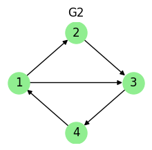

```python
import matplotlib.pyplot as plt
import networkx as nx

# Tạo đồ thị vô hướng
G = nx.DiGraph()

# Danh sách các cạnh
edges = [("1", "2"),("2", "3"),("3", "4"),("4", "1"),("1", "3")]
pos = {"1": (0, 0), "2": (0.5, 0.5), "3": (1, 0), "4": (0.5, -0.5)}
#pos = {"a": (0, 0.5), "b": (0.5, 0.5), "c": (1, 0.5), "d": (0, 0), "f": (1, 0)}
#G.add_nodes_from(["f"])
# Thêm các cạnh vào đồ thị
G.add_edges_from(edges)

# Vẽ đồ thị
plt.figure(figsize=(2, 1.75))

# Vẽ graph
nx.draw(G, pos, with_labels=True, node_color="lightgreen", node_size=500, font_size=12)
plt.title("G2")
plt.show()
```

**Định lí:** Giả sử đồ thị $G$ có $n$ đỉnh $(n\geq 3)$ và bậc của mỗi đỉnh đều lớn hơn hoặc bằng 2. Khi đó, $G$ chứa ít nhất một chu trình.

**Ví dụ:** Trong một đám đông gồm $n\geq 3$ người, mỗi người quen ít nhất với hai người khác. Khi đó, có thể chọn ra một nhóm người để xếp ngồi quanh một bàn tròn sao cho mỗi người ngồi giữa hai người mình quen.

### 5.3. Tính liên thông

### a) Đồ thị vô hướng

**Định nghĩa:** Đồ thị vô hướng được gọi là liên thông nếu luôn tìm được đường đi nối hai đỉnh bất kỳ của nó.

**Ví dụ:**

| $G_1$ và $G_2$ là các đồ thị liên thông $G=G_1\cup G_2$ không là đồ thị liên thông |  |  |
| --- | --- | --- |

**Mệnh đề:** Luôn tìm được đường đi đơn nối 2 đỉnh bất kì của đồ thị vô hướng liên thông.

**Định lí:** Một đồ thị $n$ đỉnh, mỗi đỉnh có bậc ít nhất bằng $n/2$ là đồ thị liên thông.

- Theo định nghĩa, luôn tìm được đường đi nối hai đỉnh bất kỳ của đồ thị liên thông. Gọi $P$ là đường đi ngắn nhất nối hai đỉnh $u$ và $v$. Rõ ràng $P$ phải là đường đi đơn.
- Giả sử đồ thị $G$ đã cho không liên thông. Khi đó, $G$ phải có ít nhất một thành phần liên thông $G'$ chứa không quá $n/2$ đỉnh (vì nếu không, thành phần nào cũng hơn $>n/2$ thì $G$ sẽ có quá $n$ đỉnh). Do đó mỗi đỉnh của $G'$ có bậc không quá $n/2 − 1$ (vì liên thông nên có đường đi từ $n/2-1$ đỉnh còn lại đến nó, nên tối đa là $n/2-1$ bậc). Điều này trái với giả thiết là bậc của đỉnh trong $G$ ít nhất là $n/2$.

**Thành phần liên thông:** Đồ thị con liên thông của đồ thị vô hướng $G$ được gọi là thành phần liên thông của nó.

**Ví dụ:** Đồ thị $G=G_1\cup G_2\cup G_3$ có 3 thành phần liên thông

### b) Đồ thị có hướng

**Định nghĩa:** Đồ thị có hướng được gọi là liên thông mạnh nếu luôn có một đường đi nối hai đỉnh bất kỳ của đồ thị. Đồ thị có hướng được gọi là liên thông yếu nếu đồ thị vô hướng tương ứng với nó là đồ thị vô hướng liên thông.

**Ví dụ:**

### c) Đỉnh rẽ nhánh và cầu

**Đỉnh rẽ nhánh**: là đỉnh mà việc loại bỏ nó (và các cạnh liên thuộc với nó) làm tăng số thành phần liên thông của đồ thị.

**Cầu**: là cạnh mà việc loại bỏ nó làm tăng số thành phần liên thông của đồ thị.

**Ví dụ:**

| $e$ là đỉnh rẽ nhánh Cạnh $(e,g)$ là cầu |  |
| --- | --- |

# 6. Một số loại đồ thị đặc biệt

Chỉ xét các đơn đồ thị vô hướng

### 6.1. Đồ thị đầy đủ

**Định nghĩa**: Một đồ thị được gọi là đầy đủ nếu mọi cặp đỉnh của nó đều kề nhau (có cạnh nối). Số cạnh của đồ thị đầy đủ $n$ đỉnh là $C^2_n$.

**Ví dụ:**

Trong thực tế chúng ta thường hay gặp đồ thị đầy đủ. Chẳng hạn, đồ thị biểu diễn quan hệ quen biết của các sinh viên trong một lớp học là một đồ thị đầy đủ, trong đó các đỉnh biểu thị các sinh viên, mỗi cạnh nối hai đỉnh của đồ thị biểu thị hai sinh viên tương ứng quen biết nhau.

### 6.2. Đồ thị vòng

**Định nghĩa**: Đồ thị vòng $n\geq 3$ đỉnh $v_1,v_2,\cdots,v_n$ là đồ thị gồm $n$ cạnh $(v_1,v_2)$, $(v_2,v_3)$,..., $(v_{n-1},v_n)$ và $(v_n,v_1)$

**Ví dụ:**

### 6.3. Đồ thị bánh xe

**Định nghĩa**: Đồ thị bánh xe $W_n$ gồm $n+1$ đỉnh ($n\geq 3$)thu được từ đồ thị vòng $C_n$ bằng cách bổ sung một đỉnh mới nối với tất cả các đỉnh còn lại. Số cạnh của đồ thị $W_n$ là $2n$.

**Ví dụ:**

### 6.4. Đồ thị hai phía

**Định nghĩa**:

Một đồ thị $G = (V, E)$ được gọi là đồ thị hai phía nếu các đỉnh của nó có thể được phân thành hai tập hợp con $V_1$ và $V_2$ sao cho mỗi cạnh trong $G$ nối một đỉnh của $V_1$ với một đỉnh của $V_2$.

Một đồ thị hai phía $G = (V, E)$ mà tất cả các đỉnh trong tập $V_1$ nối với tất cả các đỉnh trong $V_2$ được gọi là đồ thị hai phía đầy đủ

Kí hiệu $K_{n,m}$ là một đồ thị 2 phía đầy đủ với $n=|V_1|$, $m=|V_2|$ $(1\leq n\leq m)$. Khi đó $$|V(K_{n,m})|=n+m\text{ và }|E(K_{n,m})|=n\cdot m.$$

**Ví dụ:**

[figure not shown]

```python
import matplotlib.pyplot as plt
import networkx as nx

# Tạo đồ thị vô hướng
G = nx.Graph()

# Danh sách các cạnh
edges = [("k(1)", "b(2)"),("a(3)", "b(2)"),("k(1)", "a(3)"),("a(3)", "i(2)"), ("i(2)", "k(1)"),("k(1)", "e(2)"),("e(2)", "f(3)"),("i(2)", "f(3)"),("b(2)", "c(3)"),("d(1)", "c(3)"),("d(1)", "e(2)"),("d(1)", "b(2)"),("k(1)", "f(3)")]
pos = {"k(1)": (0, 0), "a(3)": (-0.5, 0.5), "b(2)": (0, 0.5),"c(3)": (0.5, 0.5),"d(1)": (0.5, -0.5),"e(2)": (0, -0.5),"f(3)": (-0.5, -0.5),"i(2)": (-0.5, 0)}
#G.add_nodes_from(["f"])
# Thêm các cạnh vào đồ thị
G.add_edges_from(edges)

# Vẽ đồ thị
plt.figure(figsize=(3, 3))

# Vẽ graph
nx.draw(G, pos, with_labels=True, node_color="lightgreen", node_size=1000, font_size=12)
plt.title("3-sắc")
plt.show()
```

[figure not shown]

```python
import matplotlib.pyplot as plt
import networkx as nx

# Tạo đồ thị vô hướng
G = nx.Graph()

# Danh sách các cạnh
#edges = [("i", "j"),("j", "k"),("k", "i")]
#pos = {"j": (0, 0), "i": (0.5, 0.5), "k": (1, 0)}
#pos = {"a": (0, 0.5), "b": (0.5, 0.5), "c": (1, 0.5), "d": (0, 0), "f": (1, 0)}
pos = {"f": (0, 0)}
G.add_nodes_from(["f"])
# Thêm các cạnh vào đồ thị
#G.add_edges_from(edges)

# Vẽ đồ thị
plt.figure(figsize=(1, 1))

# Vẽ graph
nx.draw(G, pos, with_labels=True, node_color="lightgreen", node_size=500, font_size=12)
plt.title("G2")
plt.show()
```

# 7. Bài toán tô màu đồ thị

Bài toán tô màu đồ thị (graph coloring) được nghiên cứu từ những năm đầu của thế kỷ XVIII và thực sự phát triển vào những năm 50 của thế kỷ XX khi mà máy tính điện tử ra đời. Bài toán tô màu đồ thị có nhiều ứng dụng trong đời sống, chẳng hạn như tô màu bản đồ, bài toán lập lịch, bài toán phân chia kênh phát sóng các đài truyền hình, bài toán phân bổ tần số cho các mạng điện thoại di động

**Định nghĩa**:

Tô màu đồ thị là việc gán mỗi đỉnh của đồ thị một màu sao cho hai đỉnh kề nhau có màu khác nhau.

Số màu tối thiểu cần thiết để tô màu đồ thị $G$ được gọi là sắc số của $G$ và ký hiệu là $\chi(G)$. Một đồ thị được gọi là $k$-sắc nếu có sắc số là $k$.

Dễ thấy rằng, đồ thị đầy đủ $K_n$ là $n$-sắc, đồ thị hai phía là $2$-sắc, đồ thị vòng $C_n$ là $3$-sắc nếu $n$ là số lẻ, là $2$-sắc nếu $n$ là số chẳn. Trong trường hợp tổng quát, việc xác định sắc số của một đồ thị là bài toán NP-Hard.

**Các định lí:**

(Konig) Một đồ thị (với ít nhất một cạnh) là đồ thị $2$-sắc khi và chỉ khi nó không có chu trình độ dài lẻ.

(Brook) Mọi đơn đồ thị liên thông $G$, ngoại trừ đồ thị đầy đủ và đồ thị vòng độ dài lẻ, đều có sắc số không quá bậc lớn nhất của các đỉnh trong $G$.

(Định lý bốn màu) Mọi đồ thị phẳng có sắc số không quá $4$.

### * Thuật toán Welch-Powell

**Bước 1** Lập danh sách $V$ các đỉnh của $G$ theo thứ tự bậc giảm dần. Đặt $i: = 1$.

**Bước 2** Sử dụng màu $i$ để tô đỉnh đầu của $V$ và các đỉnh không kề với nó và đảm bảo nguyên tắc hai đỉnh kề nhau có màu khác nhau. Loại khỏi $V$ các đỉnh đã được tô màu.

**Bước 3** Nếu $V = ∅$ thì kết thúc thuật toán, ngược lại đặt $i: = i + 1$ và quay lại **Bước 2**

**Ví dụ:**

```python
def welch_powell(graph):
    """
    Tham số: graph: dict, định nghĩa đồ thị dưới dạng
            vertex: [list các đỉnh kề]
    Trả về:
        color: dict, ánh xạ từ đỉnh đến màu được tô.
    """
    vertices = sorted(graph.keys(), key=lambda v: len(graph[v]), reverse=True) # Sắp xếp các đỉnh theo bậc giảm dần
    color = {}       # lưu màu của mỗi đỉnh
    current_color = 1

    while vertices:
        colored_this_round = []  # Tạo danh sách tạm chứa các đỉnh sẽ được tô màu hiện hành
        for v in vertices:
            conflict = False     # Kiểm tra xem đỉnh v có kề với đỉnh nào đã được gán current_color hay không
            for neighbor in graph[v]:
                if color.get(neighbor) == current_color:
                    conflict = True
                    break
            if not conflict:
                color[v] = current_color
                colored_this_round.append(v)
        vertices = [v for v in vertices if v not in colored_this_round]   # Loại bỏ các đỉnh đã tô màu ra khỏi danh sách vertices
        current_color += 1
    return color

graph = {
    'A': ['B', 'I', 'K'],
    'B': ['A', 'C', 'D', 'K'],
    'C': ['B', 'D'],
    'D': ['B', 'C', 'E'],
    'E': ['D','F','K'],
    'F': ['E','I','K'],
    'I': ['A','F','K'],
    'K': ['A','B','D','E','F','I'],
}
result_colors = welch_powell(graph)
print("Kết quả tô màu:", result_colors)
```

```
Kết quả tô màu: {'K': 1, 'D': 1, 'B': 2, 'E': 2, 'I': 2, 'A': 3, 'F': 3, 'C': 3}
```